# Datathon Team 18

Merilyn Albuquerque

2025-01-21

#Datathon Team 18 - Script for data tidy and figures for clinical characteristics

## Merge TRACERx NSCLC dataset with MSK NSCLC

Merge and tidy up to create one neat dataframe for both studies

1. Tidy up MSK data
2. Tidy up metastatic sites from multiple columns into one column (‘Metastatic.Site’) in Supplementary_Table14 document
3. Add corresponding columns to TRACERx data to match MSK (i.e. ‘Study.ID’, ‘Cancer.Type’, ‘Histology’)
4. Subset relevant columns in TRACERx, rename column names to match MSK
5. Merge TRACERx with MSK data, save file
6. Plot tables and graphs of each dataset separately and together

Things to note:

1. MSK data has duplicate patient IDs for each sample ID (multiple samples per patient) - this needs to be addressed when looking at clinical characteristics and when performing regression modelling
2. Conversely, TRACERx data has multiple met sites for one patient ID - but this can be easily tidied for better plotting
3. Overall survival in TRACERx data did not mention if it was in days (we assumed and calculated time in months to match MSK data)
4. Smoking status in MSK is TRUE (Smoker and Ex-Smoker) and FALSE (Never Smoked). Labels were changed in both datasets to help group patients into these two categories.

```r
library(dplyr)
library(tidyr)

#Load all data - TRACERx dataset, MSK dataset, Supplementary Table 14 file
all_patients_df <- readRDS("figurecode/data/20221109_TRACERx421_all_patient_df.rds")
msk_table_raw <- read.csv("MSK_NSCLC_2022_raw.csv")
supp_t14 <- readxl::read_excel("Supp_Table_14.xlsx")


#Tidy data in MSK
msk_table <- msk_table_raw[,c("Study.ID", "Patient.ID", "Sample.Type", "Cancer.Type", "Cancer.Type.Detailed",
                                  "Oncotree.Code", "Overall.Survival..Months.", "Sex", "Smoking.Status", "Patient.Current.Age",
                                  "Ethnicity.Category", "Histology", "Metastatic.Site")]
msk_table <- msk_table %>% mutate(Metastatic.Site = ifelse(Metastatic.Site == "Lymph node", "Lymph Node", Metastatic.Site))
msk_table <- msk_table %>% mutate(Smoking.Status = ifelse(Smoking.Status == "True", "Smoker/Ex-Smoker", "Never Smoked"))
colnames(msk_table) <- c("Study.ID", "Patient.ID", "Sample.Type", "Cancer.Type", "Cancer.Type.Detailed",
                                  "Oncotree.Code", "Overall.Survival..Months.", "Sex", "Smoking.Status", "Age",
                                  "Ethnicity", "Histology", "Metastatic.Site")

#Adjust met site info from Supplementary Table 14 file, merge with TRACERx file
supp_t14 <- supp_t14[-c(1:4),-c(2,4)]
colnames(supp_t14) <- supp_t14[1,]
supp_t14 <- supp_t14[-1,]
names(supp_t14)[names(supp_t14) == "PublicationID"] <- "cruk_id"
supp_t14 <- supp_t14 %>%
  mutate(across(-cruk_id, as.character))
supp_t14 <- supp_t14 %>%
  pivot_longer(-c(cruk_id), names_to = "Condition", values_to = "Value") %>%
  filter(Value == "TRUE") %>%
  group_by(cruk_id) %>%
  summarize(Combined_Conditions = paste(Condition, collapse = ", "), .groups = "drop")
colnames(supp_t14) <- c("cruk_id", "Metastatic.Site")
tracex_met_pts_df <- left_join(all_patients_df, supp_t14, by = "cruk_id")

#Tidy data in TRACERx (general tidy and adding columns to match MSK data for better merged df)
tracex_met_pts_df <- tracex_met_pts_df %>%
  mutate(Relapse_cat_new = case_when(Relapse_cat_new == "No rec" ~ "No metastasis", TRUE ~ as.character(Relapse_cat_new)))
tracex_met_pts_df <- tracex_met_pts_df %>%
  mutate(os_time = os_time/30.44)
tracex_met_pts_df$Study.ID <- "nsclc_TRACERx_2023"
tracex_met_pts_df$Cancer.Type <- "Non-Small Cell Lung Cancer"
tracex_met_pts_df$histology_multi_full_genomically.confirmed <- gsub("x2|x3", "", tracex_met_pts_df$histology_multi_full_genomically.confirmed)
tracex_met_pts_df <- tracex_met_pts_df %>%
  mutate(Histology = case_when(grepl("LUAD", histology_multi_full_genomically.confirmed) ~ "Adenocarcinoma",
                               grepl("LUSC", histology_multi_full_genomically.confirmed) ~ "Squamous Cell Carcinoma",
                               TRUE ~ histology_multi_full_genomically.confirmed))
tracex_met_pts_df <- tracex_met_pts_df %>%
  mutate(Sample.Type = case_when(grepl("Intrathoracic", Relapse_cat_new) ~ "Metastasis",
                                 grepl("Extrathoracic", Relapse_cat_new) ~ "Metastasis",
                                 grepl("Intra & Extra", Relapse_cat_new) ~ "Metastasis",
                                 grepl("Unknown Site", Relapse_cat_new) ~ "Unknown",
                                 TRUE ~ Relapse_cat_new))
tracex_met_pts_df <- tracex_met_pts_df %>%
  mutate(smoking_status_merged = case_when(grepl("Smoker", smoking_status_merged) ~ "Smoker/Ex-Smoker",
                                    grepl("Ex-Smoker", smoking_status_merged) ~ "Smoker/Ex-Smoker",
                                    TRUE ~ smoking_status_merged))


tracex_met_pts_df <- tracex_met_pts_df[,c("Study.ID", "Cancer.Type", "cruk_id",
                                          "age", "sex", "ethnicity",
                                          "os_time", "smoking_status_merged", "histology_multi_full_genomically.confirmed",
                                          "Histology", "Relapse_cat_new", "Metastatic.Site", "Sample.Type")]
colnames(tracex_met_pts_df) <- c("Study.ID", "Cancer.Type", "Patient.ID",
                                 "Age", "Sex", "Ethnicity",
                                 "Overall.Survival..Months.", "Smoking.Status", "Oncotree.Code",
                                 "Histology", "Metastatic.Category", "Metastatic.Site", "Sample.Type")

#Merge MSK dataset with TRACERx
MSK_TRACERx_merged <- full_join(tracex_met_pts_df, msk_table, by = c("Study.ID", "Patient.ID", "Cancer.Type",
                                                                     "Oncotree.Code", "Overall.Survival..Months.", "Sex",
                                                                     "Smoking.Status", "Histology", "Metastatic.Site",
                                                                     "Sample.Type", "Age"))
head(MSK_TRACERx_merged, 5)
```

```
##             Study.ID                Cancer.Type Patient.ID Age    Sex
## 1 nsclc_TRACERx_2023 Non-Small Cell Lung Cancer   CRUK0034  68 Female
## 2 nsclc_TRACERx_2023 Non-Small Cell Lung Cancer   CRUK0150  81   Male
## 3 nsclc_TRACERx_2023 Non-Small Cell Lung Cancer   CRUK0159  60   Male
## 4 nsclc_TRACERx_2023 Non-Small Cell Lung Cancer   CRUK0090  65   Male
## 5 nsclc_TRACERx_2023 Non-Small Cell Lung Cancer   CRUK0045  85   Male
##      Ethnicity.x Overall.Survival..Months.   Smoking.Status Oncotree.Code
## 1   White- Irish                  60.74244 Smoker/Ex-Smoker          LUAD
## 2 White- British                  44.74376 Smoker/Ex-Smoker         Other
## 3 White- British                  73.06176 Smoker/Ex-Smoker          LUAD
## 4 White- British                  77.69382 Smoker/Ex-Smoker          LUSC
## 5 White- British                  32.39159 Smoker/Ex-Smoker          LUAD
##                 Histology Metastatic.Category  Metastatic.Site   Sample.Type
## 1          Adenocarcinoma       No metastasis             <NA> No metastasis
## 2                   Other       No metastasis             <NA> No metastasis
## 3          Adenocarcinoma       No metastasis             <NA> No metastasis
## 4 Squamous Cell Carcinoma       Intrathoracic Mediastinal_lung    Metastasis
## 5          Adenocarcinoma       Intrathoracic             <NA>    Metastasis
##   Cancer.Type.Detailed Ethnicity.y
## 1                 <NA>        <NA>
## 2                 <NA>        <NA>
## 3                 <NA>        <NA>
## 4                 <NA>        <NA>
## 5                 <NA>        <NA>
```

```r
tail(MSK_TRACERx_merged, 5)
```

```
##                 Study.ID                Cancer.Type Patient.ID Age    Sex
## 3038 nsclc_ctdx_msk_2022 Non-Small Cell Lung Cancer  P-0058614  70 Female
## 3039 nsclc_ctdx_msk_2022  Cancer of Unknown Primary  P-0059005  67   Male
## 3040 nsclc_ctdx_msk_2022  Cancer of Unknown Primary  P-0059005  67   Male
## 3041 nsclc_ctdx_msk_2022 Non-Small Cell Lung Cancer  P-0059249  82 Female
## 3042 nsclc_ctdx_msk_2022 Non-Small Cell Lung Cancer  P-0059249  82 Female
##      Ethnicity.x Overall.Survival..Months.   Smoking.Status Oncotree.Code
## 3038        <NA>                  15.01314     Never Smoked          LUAD
## 3039        <NA>                  13.79763 Smoker/Ex-Smoker           CUP
## 3040        <NA>                  13.79763 Smoker/Ex-Smoker           PDC
## 3041        <NA>                  14.15900     Never Smoked          LUAD
## 3042        <NA>                  14.15900     Never Smoked          LUAD
##           Histology Metastatic.Category Metastatic.Site Sample.Type
## 3038 Adenocarcinoma                <NA>          Pleura  Metastasis
## 3039          Other                <NA>            <NA>  Metastasis
## 3040          Other                <NA>         Adrenal  Metastasis
## 3041 Adenocarcinoma                <NA>            <NA>  Metastasis
## 3042 Adenocarcinoma                <NA>            <NA>     Primary
##                      Cancer.Type.Detailed               Ethnicity.y
## 3038                  Lung Adenocarcinoma Non-Spanish; Non-Hispanic
## 3039            Cancer of Unknown Primary Non-Spanish; Non-Hispanic
## 3040 Poorly Differentiated Carcinoma, NOS Non-Spanish; Non-Hispanic
## 3041                  Lung Adenocarcinoma Non-Spanish; Non-Hispanic
## 3042                  Lung Adenocarcinoma Non-Spanish; Non-Hispanic
```

```r
unique_patients <- unique(MSK_TRACERx_merged$Patient.ID) #there are 1548 unique patient IDs

#write.csv(MSK_TRACERx_merged, "MSK_TRACERx_merged.csv", row.names = FALSE)
```

## TRACERx Clinical Characteristics

```r
library(tableone)

myVars <- c("Age", "Sex", "Ethnicity", "Overall.Survival..Months.", "Smoking.Status", "Histology", "Metastatic.Category")
catVars <- c("Sex", "Ethnicity", "Smoking.Status", "Histology", "Metastatic.Category")
table1 <- CreateTableOne(vars = myVars, data = tracex_met_pts_df, factorVars = catVars)
table1
```

```
##
##                                         Overall
##   n                                       421
##   Age (mean (SD))                       69.04 (9.34)
##   Sex = Male (%)                          233 (55.3)
##   Ethnicity (%)
##      Black                                  1 ( 0.2)
##      Caribbean                              4 ( 1.0)
##      Indian                                 3 ( 0.7)
##      Middle eastern                         4 ( 1.0)
##      South American                         1 ( 0.2)
##      White and Asian                        2 ( 0.5)
##      White and Black                        2 ( 0.5)
##      White- British                       371 (88.1)
##      White- Irish                          17 ( 4.0)
##      White- Other                           3 ( 0.7)
##      White-European                        13 ( 3.1)
##   Overall.Survival..Months. (mean (SD)) 38.66 (21.21)
##   Smoking.Status = Smoker/Ex-Smoker (%)   390 (92.6)
##   Histology (%)
##      Adenocarcinoma                       242 (57.5)
##      Other                                 45 (10.7)
##      Squamous Cell Carcinoma              134 (31.8)
##   Metastatic.Category (%)
##      Extrathoracic                         34 ( 8.1)
##      Intra & Extra                         43 (10.2)
##      Intrathoracic                         61 (14.5)
##      No metastasis                        279 (66.3)
##      Unknown Site                           4 ( 1.0)
```

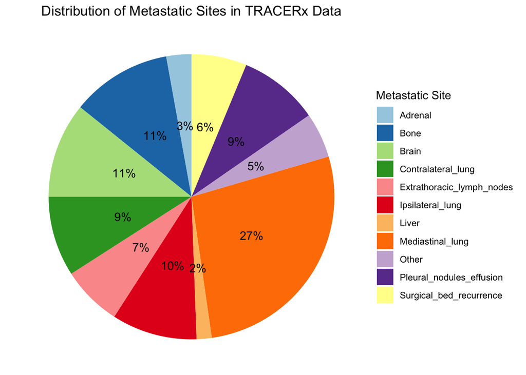

```r
library(ggplot2)

#Calculate percentages for each met site
pie_data_tracerx <- tracex_met_pts_df %>%
  filter(!is.na(Metastatic.Site)) %>%
  count(Metastatic.Site, name = "Count")

#Separate multiple met sites into individual sites for better graph
pie_data_tracerx <- pie_data_tracerx %>%
  mutate(Metastatic.Site = strsplit(Metastatic.Site, ", ")) %>%
  unnest(Metastatic.Site) %>%
  group_by(Metastatic.Site) %>%
  summarise(Count = sum(Count)) %>%
  mutate(Percentage = Count / sum(Count) * 100) %>%
  arrange(desc(Percentage))


#Plot pie chart
ggplot(pie_data_tracerx, aes(x = "", y = Percentage, fill = Metastatic.Site)) +
  geom_bar(stat = "identity", width = 1) +
  coord_polar("y") +
  theme_void() +
  labs(title = "Distribution of Metastatic Sites in TRACERx Data", fill = "Metastatic Site") +
  theme(plot.title = element_text(hjust = 0.5)) +
  scale_fill_brewer(palette = "Paired") +
  geom_text(aes(label = paste0(round(Percentage, 0), "%")),
            position = position_stack(vjust = 0.5),
            color = "black", size = 4)
```

## MSK Clinical Characteristics

```r
myVars2 <- c("Age", "Sex", "Ethnicity", "Overall.Survival..Months.", "Smoking.Status", "Histology", "Sample.Type")
catVars2 <- c("Sex", "Ethnicity", "Smoking.Status", "Histology", "Sample.Type")
table2 <- CreateTableOne(vars = myVars2, data = msk_table, factorVars = catVars2)
table2
```

```
##
##                                                         Overall
##   n                                                      2621
##   Age (mean (SD))                                       66.79 (11.55)
##   Sex = Male (%)                                         1072 (41.1)
##   Ethnicity (%)
##      Dominican Republic                                     5 ( 0.2)
##      Non-Spanish; Non-Hispanic                           2083 (93.9)
##      Other Spanish/Hispanic(incl European; excl Dom Rep     7 ( 0.3)
##      South/Central America (except Brazil)                  8 ( 0.4)
##      Spanish  NOS; Hispanic NOS, Latino NOS                59 ( 2.7)
##      Unknown whether Spanish or not                        56 ( 2.5)
##   Overall.Survival..Months. (mean (SD))                 25.57 (25.97)
##   Smoking.Status = Smoker/Ex-Smoker (%)                  1397 (53.9)
##   Histology (%)
##      Adenocarcinoma                                      2268 (86.9)
##      Other                                                201 ( 7.7)
##      Squamous Cell Carcinoma                              142 ( 5.4)
##   Sample.Type (%)
##      Local Recurrence                                       3 ( 0.1)
##      Metastasis                                          1964 (74.9)
##      Primary                                              490 (18.7)
##      Unknown                                              164 ( 6.3)
```

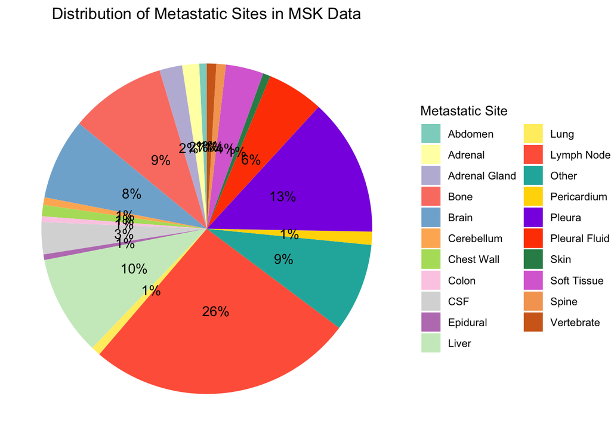

```r
library(RColorBrewer)

#Calculate percentages for each met site
pie_data_msk <- msk_table %>%
  filter(!is.na(Metastatic.Site)) %>%
  count(Metastatic.Site, name = "Count") %>%
  mutate(Percentage = Count / sum(Count) * 100) %>%
  arrange(desc(Percentage))

#Plot pie chart
#ggplot(pie_data_msk, aes(x = "", y = Percentage, fill = Metastatic.Site)) +
#  geom_bar(stat = "identity", width = 1) +
#  coord_polar("y") +
#  theme(plot.title = element_text(hjust = 0.5)) +
#  theme_void() +
#  labs(title = "Distribution of Metastatic Sites in MSK Data", fill = "Metastatic Site")


#Too many met sites - plot top 20 with remaining labelled as "Other"
top_20_msk <- pie_data_msk %>%
  arrange(desc(Percentage)) %>%
  mutate(Metastatic.Site = ifelse(row_number() > 20, "Other", Metastatic.Site)) %>%
  group_by(Metastatic.Site) %>%
  summarise(Count = sum(Count), Percentage = sum(Percentage))

set3_colors <- brewer.pal(12, "Set3")
additional_colours <- c("#FF6347", "#20B2AA", "#FFD700", "#8A2BE2", "#FF4500", "#2E8B57", "#DA70D6", "#F4A460", "#D2691E")
colours <- c(set3_colors, additional_colours)

ggplot(top_20_msk, aes(x = "", y = Percentage, fill = Metastatic.Site)) +
  geom_bar(stat = "identity", width = 1) +
  coord_polar("y") +
  theme_void() +
  labs(title = "Distribution of Metastatic Sites in MSK Data", fill = "Metastatic Site") +
  theme(plot.title = element_text(hjust = 0.5)) +
  scale_fill_manual(values = colours) +
  geom_text(aes(label = paste0(round(Percentage, 0), "%")),
            position = position_stack(vjust = 0.5),
            color = "black", size = 4)
```

## Merged (TRACERx & MSK) Clinical Characteristics

```r
#Initial table for all sample types we have across entire cohort
myVar3.1 <- c("Sample.Type")
catVars3.1 <- c("Sample.Type")
table3.1 <- CreateTableOne(vars = myVar3.1, data = MSK_TRACERx_merged, factorVars = catVars3.1)
table3.1 #3042 samples in total across 1548 patients
```

```
##
##                       Overall
##   n                   3042
##   Sample.Type (%)
##      Local Recurrence    3 ( 0.1)
##      Metastasis       2102 (69.1)
##      No metastasis     279 ( 9.2)
##      Primary           490 (16.1)
##      Unknown           168 ( 5.5)
```

```r
#Need to adjust for duplicate patient rows in MSK data to get info for remaining clinical columns
msk_table_no_pts_dups <- msk_table
msk_table_no_pts_dups[is.na(msk_table_no_pts_dups)] <- "Unknown"
msk_table_no_pts_dups <- distinct(msk_table, Patient.ID, .keep_all = TRUE)
msk_table_no_pts_dups$Age <- as.integer(msk_table_no_pts_dups$Age)

MSK_TRACERx_merged_no_pts_dups <- full_join(tracex_met_pts_df, msk_table_no_pts_dups, by = c("Study.ID", "Patient.ID", "Cancer.Type",
                                                                     "Oncotree.Code", "Overall.Survival..Months.", "Sex",
                                                                     "Smoking.Status", "Histology", "Metastatic.Site",
                                                                     "Sample.Type", "Age"))
unique_patients <- unique(MSK_TRACERx_merged_no_pts_dups$Patient.ID) #there are 1548 unique patient IDs

myVars3.2 <- c("Age", "Sex", "Ethnicity", "Overall.Survival..Months.", "Smoking.Status", "Histology")
catVars3.2 <- c("Sex", "Ethnicity", "Smoking.Status", "Histology")
table3.2 <- CreateTableOne(vars = myVars3.2, data = MSK_TRACERx_merged_no_pts_dups, factorVars = catVars3.2)
table3.2
```

```
##
##                                         Overall
##   n                                      1548
##   Age (mean (SD))                       68.12 (10.90)
##   Sex = Male (%)                          707 (46.0)
##   Overall.Survival..Months. (mean (SD)) 26.80 (23.77)
##   Smoking.Status = Smoker/Ex-Smoker (%)   974 (64.0)
##   Histology (%)
##      Adenocarcinoma                      1201 (78.1)
##      Other                                130 ( 8.5)
##      Squamous Cell Carcinoma              207 (13.5)
```

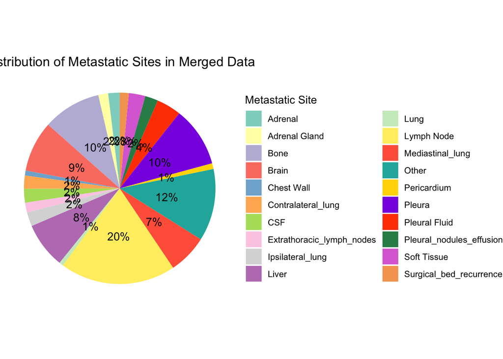

```r
#Calculate percentages for each met site
pie_data_merged <- MSK_TRACERx_merged %>%
  filter(!is.na(Metastatic.Site)) %>%
  count(Metastatic.Site, name = "Count")

#Separate multiple met sites for TRACERx into individual sites for better graph
pie_data_merged <- pie_data_merged %>%
  mutate(Metastatic.Site = strsplit(Metastatic.Site, ", ")) %>%
  unnest(Metastatic.Site) %>%
  group_by(Metastatic.Site) %>%
  summarise(Count = sum(Count)) %>%
  mutate(Percentage = Count / sum(Count) * 100) %>%
  arrange(desc(Percentage))

#Too many met sites - plot top 20 with remaining labelled as "Other"
top_20_merged <- pie_data_merged %>%
  arrange(desc(Percentage)) %>%
  mutate(Metastatic.Site = ifelse(row_number() > 20, "Other", Metastatic.Site)) %>%
  group_by(Metastatic.Site) %>%
  summarise(Count = sum(Count), Percentage = sum(Percentage)) %>% ungroup


set3_colors <- brewer.pal(12, "Set3")
additional_colours <- c("#FF6347", "#20B2AA", "#FFD700", "#8A2BE2", "#FF4500", "#2E8B57", "#DA70D6", "#F4A460", "#D2691E")
colours <- c(set3_colors, additional_colours)

ggplot(top_20_merged, aes(x = "", y = Percentage, fill = Metastatic.Site)) +
  geom_bar(stat = "identity", width = 1) +
  coord_polar("y") +
  theme_void() +
  labs(title = "Distribution of Metastatic Sites in Merged Data", fill = "Metastatic Site") +
  theme(plot.title = element_text(hjust = 0.5)) +
  scale_fill_manual(values = colours, guide = guide_legend(ncol = 2)) +
  geom_text(aes(label = paste0(round(Percentage, 0), "%")),
            position = position_stack(vjust = 0.5),
            color = "black", size = 4)
```

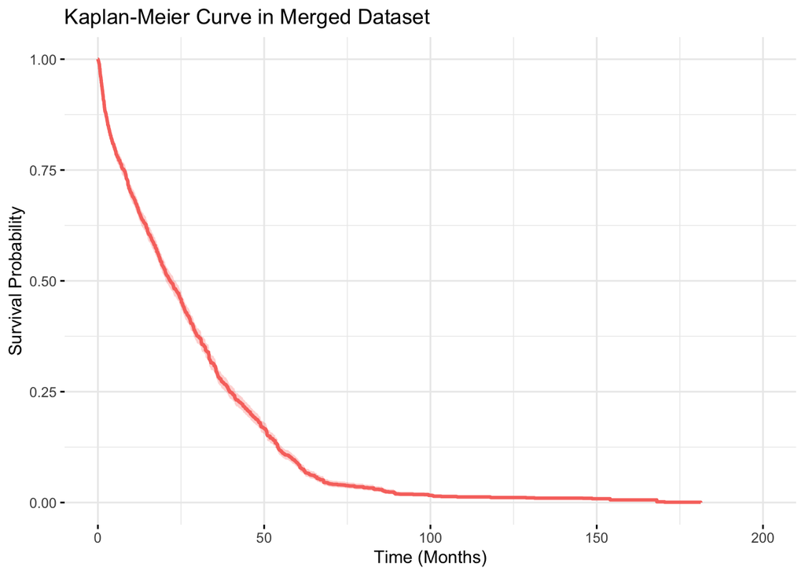

```r
library(survival)
library(survminer)
library(patchwork)

surv_obj <- Surv(time = MSK_TRACERx_merged$Overall.Survival..Months.)
fit <- survfit(surv_obj ~ 1, data = MSK_TRACERx_merged)
p1 <- ggsurvplot(
  fit,
  ggtheme = theme_minimal(),
  title = "Kaplan-Meier Curve in Merged Dataset",
  xlab = "Time (Months)",
  ylab = "Survival Probability",
  legend = "none")

fit2 <- survfit(Surv(Overall.Survival..Months.) ~ Metastatic.Category, data = MSK_TRACERx_merged)
p2 <- ggsurvplot(
  fit2,
  data = MSK_TRACERx_merged,
  ggtheme = theme_minimal(),
  title = "Kaplan-Meier Curve by Metastatic Category in TRACERx Data",
  xlab = "Time (Months)",
  ylab = "Survival Probability",
  legend = "right")

fit3 <- survfit(Surv(Overall.Survival..Months.) ~ Sample.Type, data = MSK_TRACERx_merged)
p3 <- ggsurvplot(
  fit3,
  data = MSK_TRACERx_merged,
  ggtheme = theme_minimal(),
  title = "Kaplan-Meier Curve by Sample Type in Merged Data",
  xlab = "Time (Months)",
  ylab = "Survival Probability",
  legend = "right")

fit4 <- survfit(Surv(Overall.Survival..Months.) ~ Smoking.Status, data = MSK_TRACERx_merged)
p4 <- ggsurvplot(
  fit4,
  data = MSK_TRACERx_merged,
  ggtheme = theme_minimal(),
  title = "Kaplan-Meier Curve by Smoking Status in Merged Data",
  xlab = "Time (Months)",
  ylab = "Survival Probability",
  legend = "right")

p1$plot
```

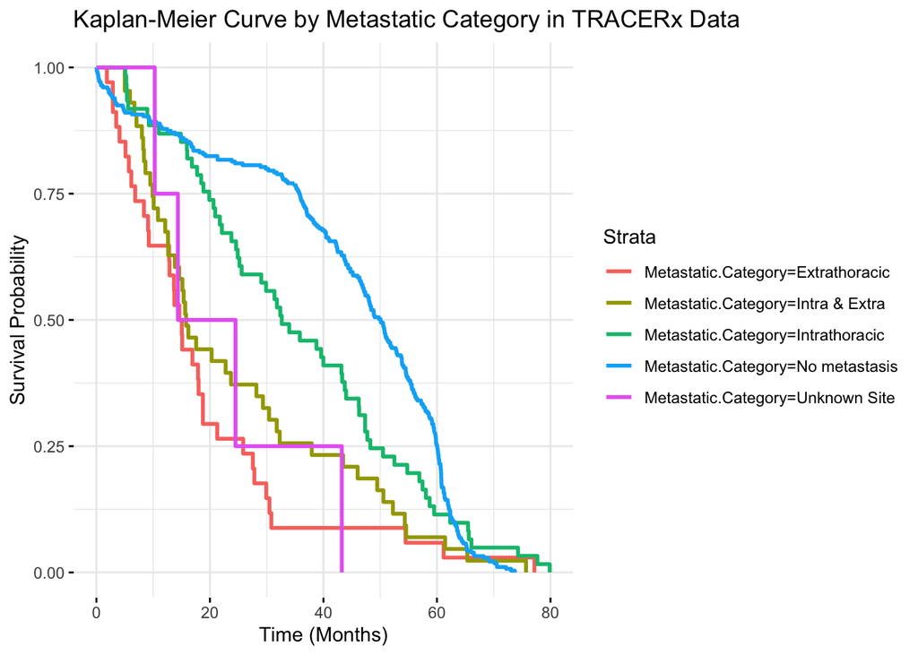

```r
p2$plot
```

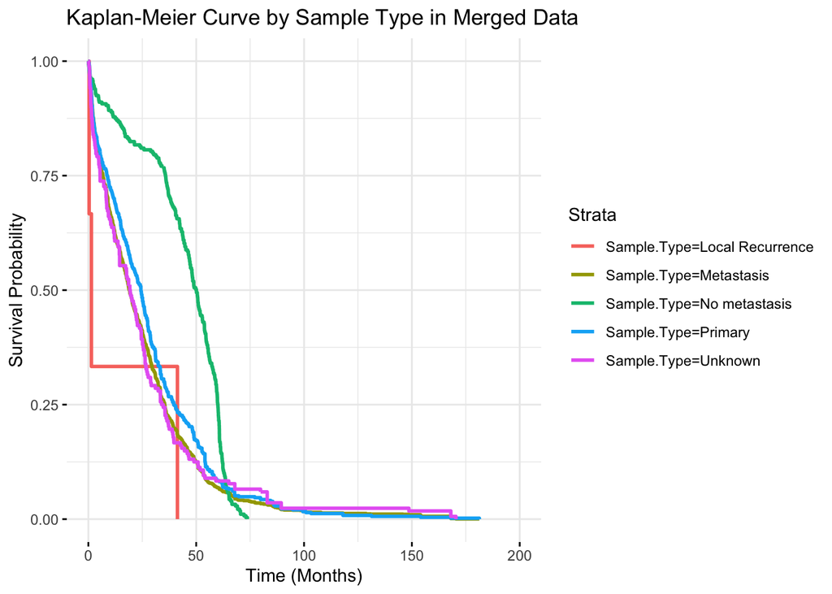

```r
p3$plot
```

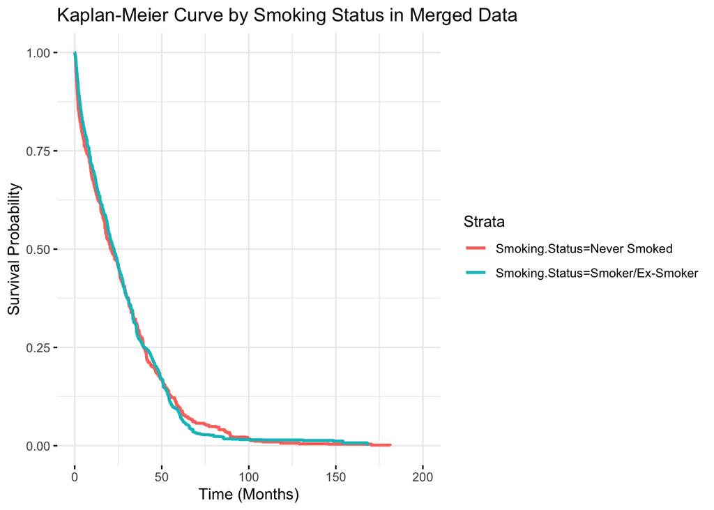

```r
p4$plot
```

```r
#ggsave("KP_plot_merged_data.png", plot=last_plot(), width = 8, height = 5)
```